# accessory gland model

Ben Bolker and Lucas Eckert

07 July 2021

**fix me**: reimplement as [target markdown](https://books.ropensci.org/targets/markdown.html#markdown) ?

```r
source("R/utils.R")
source("R/mcmc.R")
source("R/functions.R")
load_pkgs()
zmargin <- theme(panel.spacing = grid::unit(0, "lines"))
theme_set(theme_bw())
library(targets)
```

Approximate workflow:

```r
## load phylo and trait data, replace NAs with ?, combine
get_ag_data("data/binaryTraitData.csv")
## set up constrained state matrix
ag_statemat1 <- with(ag_compdata, {
  ag_smdat <- corHMM::getStateMat4Dat(data)
  pars2equal <- list(c(7, 10, 20, 23),
                     c(4, 11, 17, 24),
                     c(2, 5, 15, 18),
                     c(1, 8, 14, 21))
  equateStateMatPars(ag_smdat$rate.mat, pars2equal)
})
## run basic model and add state/parameter names
ag_model0 <- augment_model(
    corHMM(phy = ag_compdata$phy,
           data = ag_compdata$data,
           rate.cat = 1,
           rate.mat = ag_statemat1)
)
ag_mcmc0 <- corhmm_mcmc(ag_model0,
              p_args = list(nllfun = make_nllfun(ag_model0)),
              n_cores = 8,
              n_chains = 8,
              ## these are per chain
              n_burnin = 4000,
              n_iter = 44000,
              n_thin = 10,
              seed = 101)
```

**fixme**: get rid of tidyverse msgs?

```r
tar_visnetwork(targets_only = TRUE)
```

[interactive chart not shown]

## some attempts at data viz

Numbers of tips in each category (`pc` = male parental care; `sc` = sperm competition (i.e. group spawning); `ag` = accessory glands), depending on whether we use the partial (but fully genetically resolved) tree (`fishphylo`) or the imputed trees (`treeblock`).

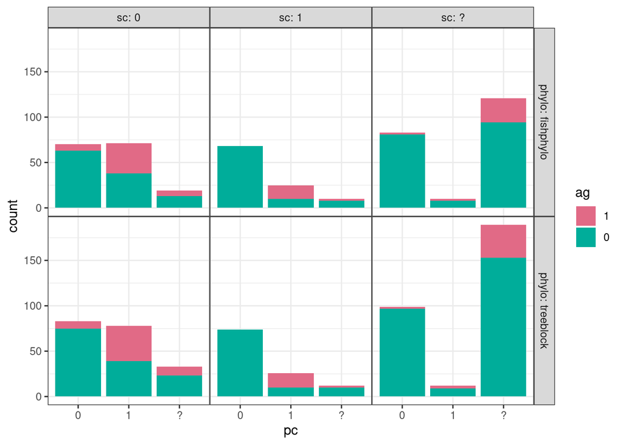

```r
tar_load(ag_compdata)
tar_load(ag_compdata_tb)
barplot_trans <- (.
  %>% mutate(across(c(pc, sc), factor, levels = c(0:1, "?")))
  %>% mutate(across(ag, factor, levels = 1:0)) ## reverse order to get ag=1 on top of bars
)
bar_data <- purrr::map_dfr(list(fishphylo = ag_compdata$data,
                    treeblock = ag_compdata_tb$data),
               barplot_trans,
               .id = "phylo")
gg1 <- (ggplot(bar_data, aes(x=pc, fill = ag))
  + geom_bar()
  + facet_grid(phylo~sc, labeller = label_both)
  + scale_fill_discrete_qualitative()
  + zmargin
)
print(gg1)
```

## priors

- all rates: from 1 (1 transition per tree) to 10*ntips (10 trans per species)
- `pc`: gain/loss ratio from 0.1 to 5
- `sc`: gain/loss ratio from 5 to 10
- `ag`: gain/loss ratio from 0.001 to 10

Use each of these as the basis for a +/- 3 sigma range (on the log scale)

```r
tar_load(ag_model0)
tar_load(ag_mcmc0)
tar_load(all_ci)
```

## Bayesian

### naming parameters

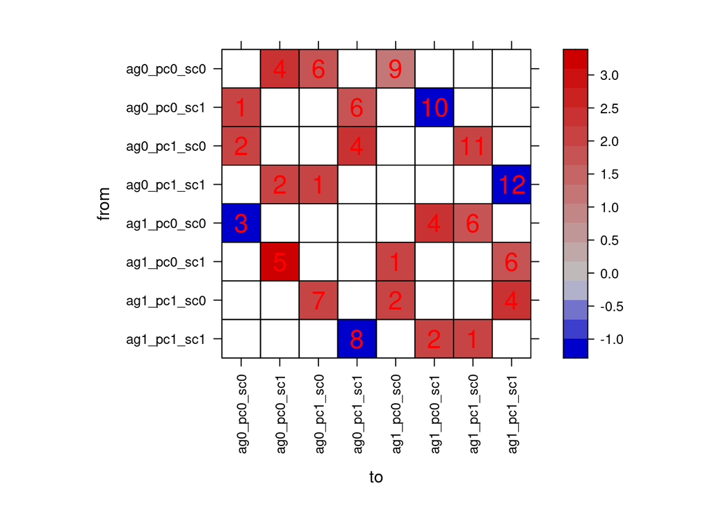

```r
image(ag_model0)
```

Auto-names:

```r
par_names(ag_model0)
```

```
##  [1] "loss.sc"         "loss.pc"         "loss.ag_pc0_sc0" "gain.sc"
##  [5] "loss.ag_pc0_sc1" "gain.pc"         "loss.ag_pc1_sc0" "loss.ag_pc1_sc1"
##  [9] "gain.ag_pc0_sc0" "gain.ag_pc0_sc1" "gain.ag_pc1_sc0" "gain.ag_pc1_sc1"
```

## Contrasts matrix

This connects the parameters we estimate (e.g. `loss.ag_pc0_sc0`, loss rate of accessory glands when parental care and sperm competition are both absent) to the values we are interested in (e.g. `pc_loss`, effect of parental care on loss rate of accessory glands).

**fixme**:

- reorder matrix for visualization?
- include weights by (imputed) state occupancy?

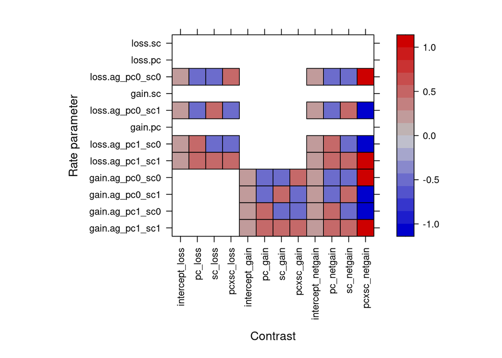

```r
tar_load(contrast_mat)
image_plot(contrast_mat, xlab = "Contrast", ylab = "Rate parameter")
```

Distribution of states in the tree (computed from stochastic character mapping, histograms represent 100 simulations):

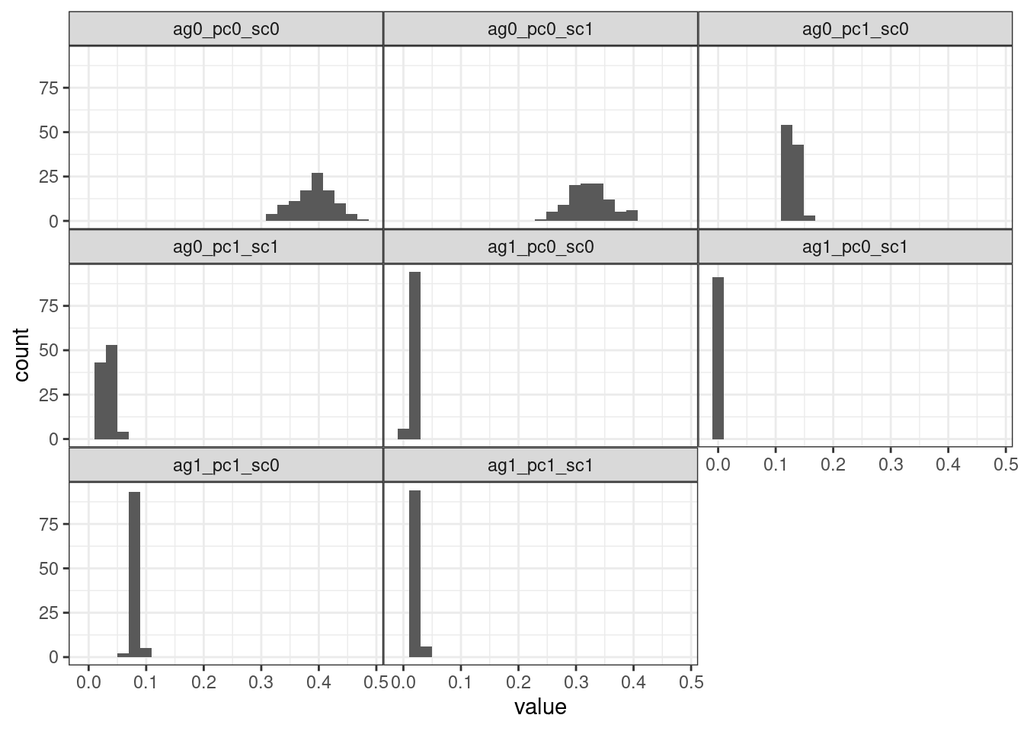

```r
tar_load(states_df)
pivot_longer(states_df, everything(), names_to = "state") %>%
  ggplot(aes(x=value)) + geom_histogram(bins=25) + facet_wrap(~state) + zmargin
```

```r
## sum columns then divide by total to get sum == 1
avg_states <- apply(states_df, 2, sum, na.rm = TRUE) / sum(states_df, na.rm = TRUE)
```

Need to figure out weights e.g. if we want the intercept for `loss.ag` it should be something like:

```r
intercept_loss <- sum(occ.ag0_pc{i}_sc{j} * loss.ag_pc{i}_sc{j})
pc_loss <- (sum(occ.ag0_pc1_sc{i} * loss.ag_pc1_sc{i}) - sum(occ.ag0_pc0_sc{i} * loss.ag_pc0_sc{i})) /
  sum(occ.ag0_pc{i}_sc{j})
```

etc. …

**FIXME**: think more about net gain and how to characterize it. Certainly should *not* be exponentiated, so leave it out here …

```r
## playing with contrasts definitions/scaling
dd <- expand.grid(f1=letters[1:2], f2 = LETTERS[1:2])
m <- model.matrix(~f1*f2, data=dd, contrasts = list(f1=contr.sum, f2=contr.sum))
t(solve(m))
## cols 2 and 3 have magnitude 1/4 but we want 1/2 (diff between treatments, not dev between
## ttt and mean)
```

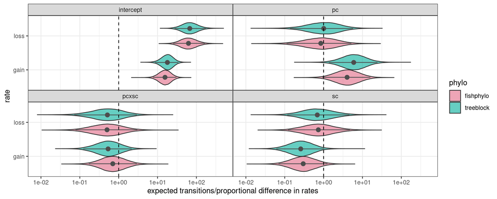

```r
tar_load(contr_long_ag_mcmc0)
tar_load(contr_long_ag_mcmc_tb)
ag_contr_gainloss <- purrr::map_dfr(list(fishphylo=contr_long_ag_mcmc0,
                                         treeblock=contr_long_ag_mcmc_tb),
                                    filter, rate != "netgain",
                                    .id = "phylo")

## ag_contr_gainloss %>% group_by(contrast, rate) %>% summarise(value=mean(value), .groups = "drop")
gg_sum <- ggplot(ag_contr_gainloss, aes(x = exp(value), y = rate)) +
  facet_wrap(~ contrast) +
  geom_violin(aes(fill = phylo), alpha=0.6) +
  stat_summary(fun.data = "median_hilow", geom = "pointrange", aes(group=phylo),
               ## width by trial and error; not sure what determines this?
               position = position_dodge(width=0.875),
               colour = "gray30") +
  geom_vline(xintercept = 1, lty = 2) +
  scale_x_log10() +
  zmargin +
  scale_fill_discrete_qualitative() +
  scale_colour_discrete_qualitative() +
  labs(x="expected transitions/proportional difference in rates")
print(gg_sum)
```

Note: values below are still on log scale …

```r
bayes_pval <- function(x, ref=0) {
  x <- mean(x<ref)
  2 * min(x, 1-x)
}
(ag_contr_gainloss
  %>% group_by(phylo,contrast,rate)
  %>% summarise(median = median(value), lwr = quantile(value, 0.025), upr = quantile(value, 0.975), p = bayes_pval(value), .groups = "drop")
  %>% knitr::kable(digits = 3)
)
```

| phylo | contrast | rate | median | lwr | upr | p |
| --- | --- | --- | --- | --- | --- | --- |
| fishphylo | intercept | gain | 2.746 | 2.028 | 3.425 | 0.000 |
| fishphylo | intercept | loss | 4.136 | 3.227 | 5.117 | 0.000 |
| fishphylo | pc | gain | 1.393 | -0.078 | 2.775 | 0.063 |
| fishphylo | pc | loss | -0.165 | -2.195 | 1.648 | 0.863 |
| fishphylo | pcxsc | gain | -0.349 | -1.771 | 1.074 | 0.632 |
| fishphylo | pcxsc | loss | -0.690 | -2.557 | 1.107 | 0.448 |
| fishphylo | sc | gain | -1.207 | -2.668 | 0.227 | 0.099 |
| fishphylo | sc | loss | -0.311 | -2.110 | 1.556 | 0.732 |
| treeblock | intercept | gain | 2.887 | 2.154 | 3.542 | 0.000 |
| treeblock | intercept | loss | 4.213 | 3.311 | 5.168 | 0.000 |
| treeblock | pc | gain | 1.786 | 0.309 | 3.194 | 0.020 |
| treeblock | pc | loss | 0.008 | -1.993 | 1.752 | 0.994 |
| treeblock | pcxsc | gain | -0.627 | -2.098 | 0.770 | 0.382 |
| treeblock | pcxsc | loss | -0.668 | -2.634 | 1.080 | 0.468 |
| treeblock | sc | gain | -1.354 | -2.800 | 0.036 | 0.056 |
| treeblock | sc | loss | -0.373 | -2.149 | 1.536 | 0.697 |

**Conclusion**: treeblock and fishphylo results are nearly identical, treeblock results are *slightly* clearer.

**fixme**: reverse legend order? figure out why `loss.sc` decreases under Bayes?

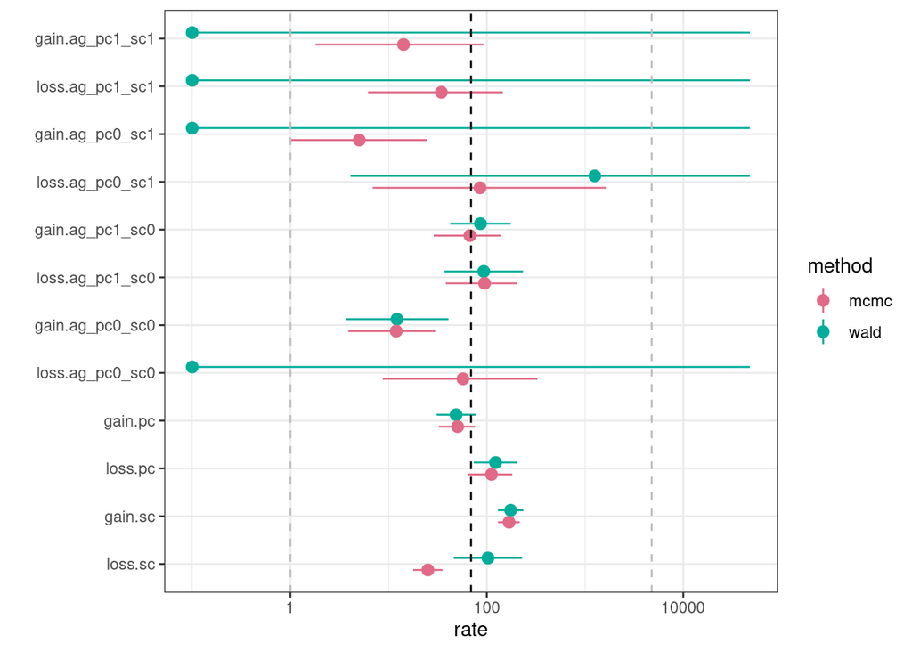

```r
## order of parameters
levs <- c(outer(FUN = paste, sep = ".",
      c("loss", "gain"),
      c("sc", "pc",
        paste0("ag_", c(outer(paste0("pc", 0:1), paste0("sc", 0:1), paste, sep = "_"))))
      ))
corhmm_bounds <- log(c(lwr=0.1, upper = 100*ape::Ntip(ag_compdata$phy)))
corhmm_prior <- log(c(lwr=1, upper = 10*ape::Ntip(ag_compdata$phy)))
corhmm_mid <- mean(corhmm_bounds)
all_ci <- all_ci %>% replace_na(list(upr = Inf, lwr = -Inf)) %>%
  mutate(across(term, factor, levels = levs))
## extend NA confidence interval to limit of graph
ggplot(
  all_ci,
  aes(term, exp(estimate), ymin = exp(lwr), ymax = exp(upr), colour = method)
) +
  geom_pointrange(position = position_dodge(width = 0.5)) +
  scale_colour_discrete_qualitative() +
  scale_y_log10(limits = exp(corhmm_bounds), oob = scales::squish) +
  coord_flip() +
  labs(y="rate", x = "") +
  geom_hline(yintercept =exp(corhmm_mid), lty=2) +
  geom_hline(yintercept = exp(corhmm_prior), lty=2, col="gray")
```

```r
## mcmc only
ggplot(
  all_ci %>% filter(method=="mcmc"),
  aes(y=term, x=exp(estimate), xmin = exp(lwr), xmax = exp(upr))) +
  geom_pointrange() +
  scale_x_log10()
```

```r
mcmc_long <- (ag_mcmc0
  %>% as.mcmc()
  %>% as_tibble()
  %>% pivot_longer(everything(), names_to = "term")
)
```